# DATA252: Variable Selection and Regularization

## Learning Objectives

In this lesson students will learn how to implement…

- Best Subset Selection
- Stepwise Selection (Backward and Forward)
- Ridge Regression
- LASSO Regression

### Ex 1: Health and Biostatistics

Use the following data for these examples:

```r
library(tidyverse)

#install.packages("faraway")
library(faraway)
set.seed(1212)

data("fat")
help(fat)
```

Read about the `fat` dataset

```r
help(fat)
```

Our goal is to predict percent of body fat from Brozek’s equation.

#### Visualize

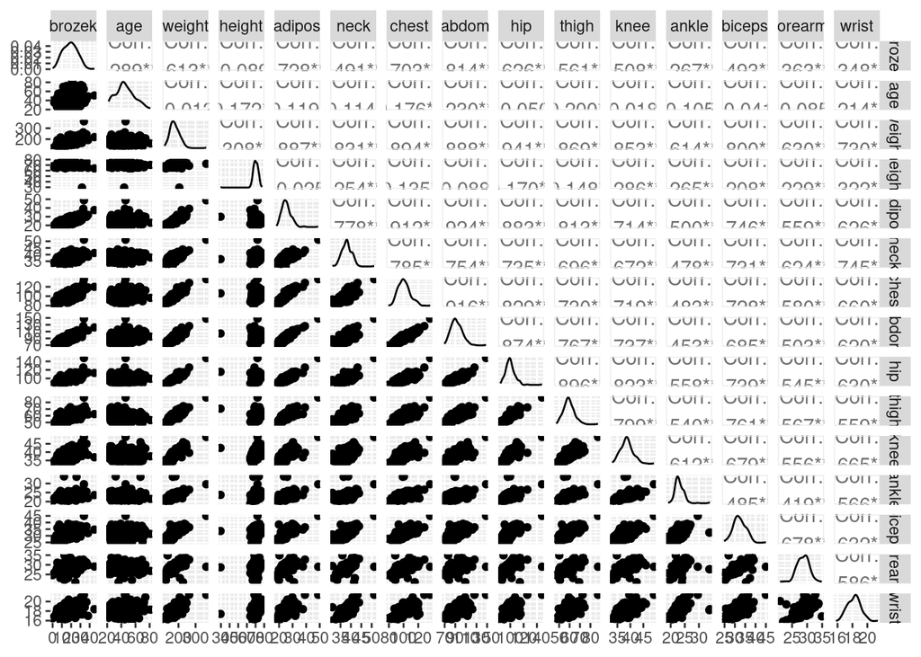

```r
#install.packages("GGally")
library(GGally)

ggpairs(fat, columns=c("brozek", "age", "weight", "height",
                       "adipos", "neck", "chest", "abdom",
                       "hip", "thigh", "knee", "ankle", "biceps",
                       "forearm", "wrist"))
```

## Stepwise Selection

In stepwise selection you take steps to add variables into the model or take them out of the model one at a time.

### Forward Selection

```r
#install.packages("leaps")
library(leaps)

### forward
model.fwrd <- regsubsets(brozek ~ age + weight +
                           height + adipos +
                           neck + chest +
                           abdom + hip + thigh +
                           knee + ankle +
                           biceps + forearm +
                           wrist,
                         data = fat,
                         nvmax = 14,
                         method = "forward")
summary(model.fwrd)
```

```
## Subset selection object
## Call: regsubsets.formula(brozek ~ age + weight + height + adipos +
##     neck + chest + abdom + hip + thigh + knee + ankle + biceps +
##     forearm + wrist, data = fat, nvmax = 14, method = "forward")
## 14 Variables  (and intercept)
##         Forced in Forced out
## age         FALSE      FALSE
## weight      FALSE      FALSE
## height      FALSE      FALSE
## adipos      FALSE      FALSE
## neck        FALSE      FALSE
## chest       FALSE      FALSE
## abdom       FALSE      FALSE
## hip         FALSE      FALSE
## thigh       FALSE      FALSE
## knee        FALSE      FALSE
## ankle       FALSE      FALSE
## biceps      FALSE      FALSE
## forearm     FALSE      FALSE
## wrist       FALSE      FALSE
## 1 subsets of each size up to 14
## Selection Algorithm: forward
##           age weight height adipos neck chest abdom hip thigh knee ankle biceps
## 1  ( 1 )  " " " "    " "    " "    " "  " "   "*"   " " " "   " "  " "   " "
## 2  ( 1 )  " " "*"    " "    " "    " "  " "   "*"   " " " "   " "  " "   " "
## 3  ( 1 )  " " "*"    " "    " "    " "  " "   "*"   " " " "   " "  " "   " "
## 4  ( 1 )  " " "*"    " "    " "    " "  " "   "*"   " " " "   " "  " "   " "
## 5  ( 1 )  " " "*"    " "    " "    "*"  " "   "*"   " " " "   " "  " "   " "
## 6  ( 1 )  "*" "*"    " "    " "    "*"  " "   "*"   " " " "   " "  " "   " "
## 7  ( 1 )  "*" "*"    " "    " "    "*"  " "   "*"   " " "*"   " "  " "   " "
## 8  ( 1 )  "*" "*"    " "    " "    "*"  " "   "*"   "*" "*"   " "  " "   " "
## 9  ( 1 )  "*" "*"    " "    " "    "*"  " "   "*"   "*" "*"   " "  " "   "*"
## 10  ( 1 ) "*" "*"    " "    " "    "*"  " "   "*"   "*" "*"   " "  "*"   "*"
## 11  ( 1 ) "*" "*"    "*"    " "    "*"  " "   "*"   "*" "*"   " "  "*"   "*"
## 12  ( 1 ) "*" "*"    "*"    " "    "*"  "*"   "*"   "*" "*"   " "  "*"   "*"
## 13  ( 1 ) "*" "*"    "*"    "*"    "*"  "*"   "*"   "*" "*"   " "  "*"   "*"
## 14  ( 1 ) "*" "*"    "*"    "*"    "*"  "*"   "*"   "*" "*"   "*"  "*"   "*"
##           forearm wrist
## 1  ( 1 )  " "     " "
## 2  ( 1 )  " "     " "
## 3  ( 1 )  " "     "*"
## 4  ( 1 )  "*"     "*"
## 5  ( 1 )  "*"     "*"
## 6  ( 1 )  "*"     "*"
## 7  ( 1 )  "*"     "*"
## 8  ( 1 )  "*"     "*"
## 9  ( 1 )  "*"     "*"
## 10  ( 1 ) "*"     "*"
## 11  ( 1 ) "*"     "*"
## 12  ( 1 ) "*"     "*"
## 13  ( 1 ) "*"     "*"
## 14  ( 1 ) "*"     "*"
```

#### Final Model

```r
which.min(summary(model.fwrd)$cp)
```

```
## [1] 8
```

```r
coef(model.fwrd, id=8)
```

```
##  (Intercept)          age       weight         neck        abdom          hip
## -20.06213373   0.05921577  -0.08413521  -0.43189267   0.87720667  -0.18641032
##        thigh      forearm        wrist
##   0.28644340   0.48254563  -1.40486912
```

### Backward Selection

```r
model.bwrd <- regsubsets(brozek ~ age + weight +
                           height + adipos +
                           neck + chest +
                           abdom + hip + thigh +
                           knee + ankle +
                           biceps + forearm +
                           wrist,
                         data = fat,
                         nvmax = 14,
                         method = "backward")
summary(model.bwrd)
```

```
## Subset selection object
## Call: regsubsets.formula(brozek ~ age + weight + height + adipos +
##     neck + chest + abdom + hip + thigh + knee + ankle + biceps +
##     forearm + wrist, data = fat, nvmax = 14, method = "backward")
## 14 Variables  (and intercept)
##         Forced in Forced out
## age         FALSE      FALSE
## weight      FALSE      FALSE
## height      FALSE      FALSE
## adipos      FALSE      FALSE
## neck        FALSE      FALSE
## chest       FALSE      FALSE
## abdom       FALSE      FALSE
## hip         FALSE      FALSE
## thigh       FALSE      FALSE
## knee        FALSE      FALSE
## ankle       FALSE      FALSE
## biceps      FALSE      FALSE
## forearm     FALSE      FALSE
## wrist       FALSE      FALSE
## 1 subsets of each size up to 14
## Selection Algorithm: backward
##           age weight height adipos neck chest abdom hip thigh knee ankle biceps
## 1  ( 1 )  " " " "    " "    " "    " "  " "   "*"   " " " "   " "  " "   " "
## 2  ( 1 )  " " "*"    " "    " "    " "  " "   "*"   " " " "   " "  " "   " "
## 3  ( 1 )  " " "*"    " "    " "    " "  " "   "*"   " " " "   " "  " "   " "
## 4  ( 1 )  " " "*"    " "    " "    " "  " "   "*"   " " " "   " "  " "   " "
## 5  ( 1 )  "*" "*"    " "    " "    " "  " "   "*"   " " " "   " "  " "   " "
## 6  ( 1 )  "*" "*"    " "    " "    " "  " "   "*"   " " "*"   " "  " "   " "
## 7  ( 1 )  "*" "*"    " "    " "    "*"  " "   "*"   " " "*"   " "  " "   " "
## 8  ( 1 )  "*" "*"    " "    " "    "*"  " "   "*"   "*" "*"   " "  " "   " "
## 9  ( 1 )  "*" "*"    " "    " "    "*"  " "   "*"   "*" "*"   " "  " "   "*"
## 10  ( 1 ) "*" "*"    " "    " "    "*"  " "   "*"   "*" "*"   " "  "*"   "*"
## 11  ( 1 ) "*" "*"    "*"    " "    "*"  " "   "*"   "*" "*"   " "  "*"   "*"
## 12  ( 1 ) "*" "*"    "*"    " "    "*"  "*"   "*"   "*" "*"   " "  "*"   "*"
## 13  ( 1 ) "*" "*"    "*"    "*"    "*"  "*"   "*"   "*" "*"   " "  "*"   "*"
## 14  ( 1 ) "*" "*"    "*"    "*"    "*"  "*"   "*"   "*" "*"   "*"  "*"   "*"
##           forearm wrist
## 1  ( 1 )  " "     " "
## 2  ( 1 )  " "     " "
## 3  ( 1 )  " "     "*"
## 4  ( 1 )  "*"     "*"
## 5  ( 1 )  "*"     "*"
## 6  ( 1 )  "*"     "*"
## 7  ( 1 )  "*"     "*"
## 8  ( 1 )  "*"     "*"
## 9  ( 1 )  "*"     "*"
## 10  ( 1 ) "*"     "*"
## 11  ( 1 ) "*"     "*"
## 12  ( 1 ) "*"     "*"
## 13  ( 1 ) "*"     "*"
## 14  ( 1 ) "*"     "*"
```

#### Final Model

```r
which.min(summary(model.bwrd)$cp)
```

```
## [1] 8
```

```r
coef(model.bwrd, id=8)
```

```
##  (Intercept)          age       weight         neck        abdom          hip
## -20.06213373   0.05921577  -0.08413521  -0.43189267   0.87720667  -0.18641032
##        thigh      forearm        wrist
##   0.28644340   0.48254563  -1.40486912
```

### Best Subset Selection

There are $2^p$ possible models to explore. Best Subset Selection finds the best set of variables for a model of a given size.

```r
### BEST SUBSET

bestsub.model <- regsubsets(brozek ~ age +
                              weight + height +
                              adipos +
                              neck + chest +
                              abdom + hip +
                              thigh + knee +
                              ankle +biceps +
                              forearm + wrist,
                            data = fat, nvmax = 14)

# nvmax: max size of subsets

summary(bestsub.model)
```

```
## Subset selection object
## Call: regsubsets.formula(brozek ~ age + weight + height + adipos +
##     neck + chest + abdom + hip + thigh + knee + ankle + biceps +
##     forearm + wrist, data = fat, nvmax = 14)
## 14 Variables  (and intercept)
##         Forced in Forced out
## age         FALSE      FALSE
## weight      FALSE      FALSE
## height      FALSE      FALSE
## adipos      FALSE      FALSE
## neck        FALSE      FALSE
## chest       FALSE      FALSE
## abdom       FALSE      FALSE
## hip         FALSE      FALSE
## thigh       FALSE      FALSE
## knee        FALSE      FALSE
## ankle       FALSE      FALSE
## biceps      FALSE      FALSE
## forearm     FALSE      FALSE
## wrist       FALSE      FALSE
## 1 subsets of each size up to 14
## Selection Algorithm: exhaustive
##           age weight height adipos neck chest abdom hip thigh knee ankle biceps
## 1  ( 1 )  " " " "    " "    " "    " "  " "   "*"   " " " "   " "  " "   " "
## 2  ( 1 )  " " "*"    " "    " "    " "  " "   "*"   " " " "   " "  " "   " "
## 3  ( 1 )  " " "*"    " "    " "    " "  " "   "*"   " " " "   " "  " "   " "
## 4  ( 1 )  " " "*"    " "    " "    " "  " "   "*"   " " " "   " "  " "   " "
## 5  ( 1 )  " " "*"    " "    " "    "*"  " "   "*"   " " " "   " "  " "   " "
## 6  ( 1 )  "*" "*"    " "    " "    " "  " "   "*"   " " "*"   " "  " "   " "
## 7  ( 1 )  "*" "*"    " "    " "    "*"  " "   "*"   " " "*"   " "  " "   " "
## 8  ( 1 )  "*" "*"    " "    " "    "*"  " "   "*"   "*" "*"   " "  " "   " "
## 9  ( 1 )  "*" "*"    " "    " "    "*"  " "   "*"   "*" "*"   " "  " "   "*"
## 10  ( 1 ) "*" "*"    " "    " "    "*"  " "   "*"   "*" "*"   " "  "*"   "*"
## 11  ( 1 ) "*" "*"    "*"    " "    "*"  " "   "*"   "*" "*"   " "  "*"   "*"
## 12  ( 1 ) "*" "*"    "*"    " "    "*"  "*"   "*"   "*" "*"   " "  "*"   "*"
## 13  ( 1 ) "*" "*"    "*"    "*"    "*"  "*"   "*"   "*" "*"   " "  "*"   "*"
## 14  ( 1 ) "*" "*"    "*"    "*"    "*"  "*"   "*"   "*" "*"   "*"  "*"   "*"
##           forearm wrist
## 1  ( 1 )  " "     " "
## 2  ( 1 )  " "     " "
## 3  ( 1 )  " "     "*"
## 4  ( 1 )  "*"     "*"
## 5  ( 1 )  "*"     "*"
## 6  ( 1 )  "*"     "*"
## 7  ( 1 )  "*"     "*"
## 8  ( 1 )  "*"     "*"
## 9  ( 1 )  "*"     "*"
## 10  ( 1 ) "*"     "*"
## 11  ( 1 ) "*"     "*"
## 12  ( 1 ) "*"     "*"
## 13  ( 1 ) "*"     "*"
## 14  ( 1 ) "*"     "*"
```

#### Model Metrics

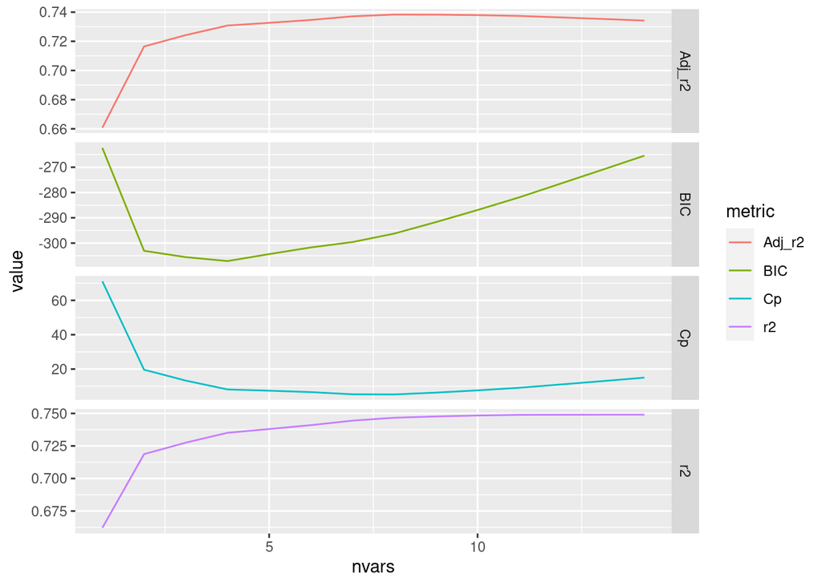

```r
#Performance measures
best14<-data.frame(nvars=1:14,
  Cp     = summary(bestsub.model)$cp,
  r2     = summary(bestsub.model)$rsq,
  Adj_r2 = summary(bestsub.model)$adjr2,
  BIC    =summary(bestsub.model)$bic)%>%
  gather(metric, value, -c(nvars))

ggplot(best14, aes(x=nvars, y=value, color=metric))+
  geom_line()+
  facet_grid(metric~., scales = "free")
```

```r
which.max(summary(bestsub.model)$adjr2)
```

```
## [1] 8
```

```r
which.min(summary(bestsub.model)$bic)
```

```
## [1] 4
```

```r
which.min(summary(bestsub.model)$cp)
```

```
## [1] 8
```

```r
which.max(summary(bestsub.model)$rsq)
```

```
## [1] 14
```

#### Cross-Validation

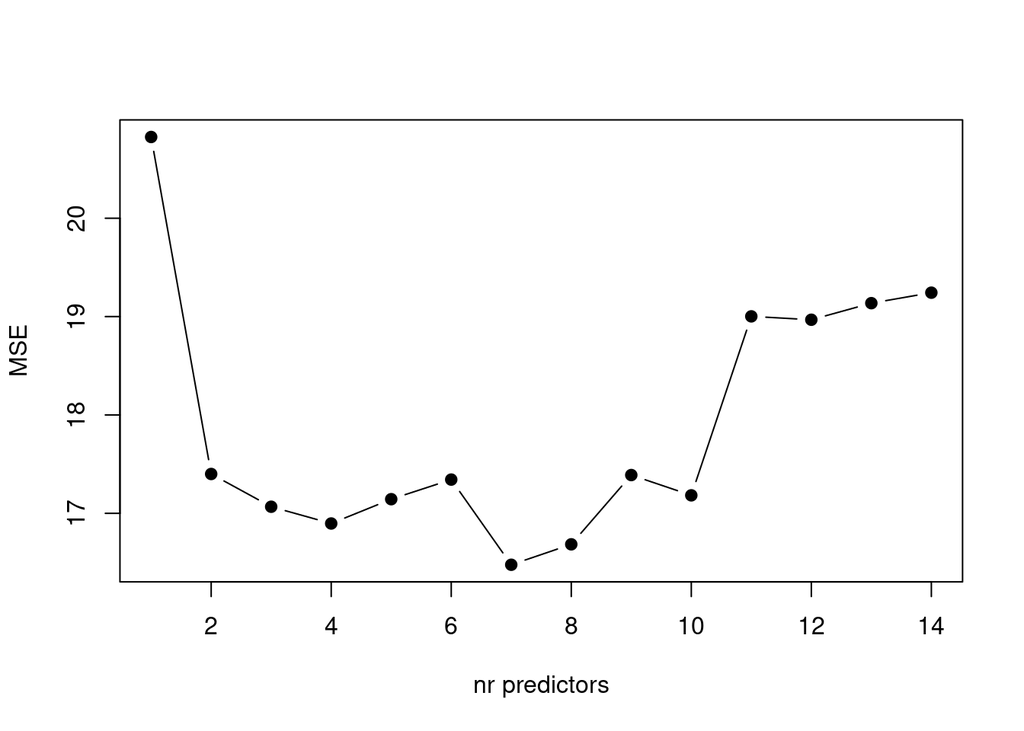

```r
##jack-knife validation (leave-one-out)

##Function to get predictions from the regsubset function
predict.regsubsets <- function(object, newdata, id,...){
  form  <- as.formula(object$call[[2]])
  mat   <- model.matrix(form, newdata)
  coefi <- coef(object, id=id)
  mat[, names(coefi)]%*%coefi
}

#store the prediction error n=252
jk.errors <- matrix(NA, 252, 14)

for (k in 1:252){
  #uses regsubsets in the data with 1 observation removed
  best.model.cv <- regsubsets(brozek ~ age +
                                weight + height +
                                adipos + neck + chest +
                                abdom + hip + thigh +
                                knee + ankle + biceps +
                                forearm + wrist,
                              data = fat[-k,],          #removes the kth obsv
                              nvmax = 14)

  #Models with 1, 2 ,...14 predictors
  for (i in 1:14){
    #that was left out
    pred <- predict.regsubsets(best.model.cv,                 #prediction in the obsv
                    fat[k,],
                    id=i)
    jk.errors[k,i] <- (fat$brozek[k]-pred)^2       #error in the obsv
  }
}

mse.models <- apply(jk.errors, 2, mean)            #MSE estimation
plot(mse.models ,                              #Plot with MSEs
     pch=19, type="b",
     xlab="nr predictors",
     ylab="MSE")
```

#### Final Model

The best final model has 7 variables.

```r
coef(bestsub.model, id=7)
```

```
##  (Intercept)          age       weight         neck        abdom        thigh
## -30.17420140   0.06149174  -0.11235658  -0.37203479   0.85152008   0.20972568
##      forearm        wrist
##   0.51823595  -1.40081475
```

#### Questions

- How would this final model change if you used a different model metric?

### Potential Problems

Collinearity/Multicollinaearity: The situation in which two or more predictor variables are related to each other.

Why is this a problem?

- Increased variance (increased standard error)
- Decreased t-statistics
- Increased p-value

A way to quantify the impact of multicollinearity is to look at the VIF (variance inflation factor). A VIF close to 1 would imply no correlation. The larger the VIF the larger the amount of multicollinearity.

$$VIF(\hat{\beta}_j)=\frac{1}{1-R^2_{X_j|X_{-j}}}$$

The general rule of thumb is that VIFs exceeding 4 warrant further investigation, while VIFs exceeding 10 are signs of serious multicollinearity requiring correction.

```r
library(car)
vif(lm(brozek ~  age + weight +                 #OLS
                       height + adipos +
                       neck + chest +
                       abdom + hip + thigh +
                       knee + ankle +
                       biceps + forearm +
                       wrist, data=fat))
```

```
##       age    weight    height    adipos      neck     chest     abdom       hip
##  2.250902 33.786851  2.256593 16.163444  4.430734 10.684562 13.346689 15.158277
##     thigh      knee     ankle    biceps   forearm     wrist
##  7.961508  4.828828  1.945514  3.674508  2.193390  3.379612
```

#### Question:

- Are there variables that we should be concerned about exhibiting multicollinearity?

## Regularization Methods

Regularization methods modify the loss function (see below). One of the benefits of using regularization methods is that they protect against multicollinearity.

### Ridge Regression

Ridge regression minimizes the residual sum of squares with an $L2$ penalty.

$$\sum_{i=1}^n(y_i-\beta_0-\sum_{j=1}^p\beta_jx_{ij})^2+\lambda\sum_{j=1}^p\beta_j^2$$

Big Ideas:

- This shrinks $\beta_j$ coefficients toward zero
- Stills works with multicollinarity

```r
### ridge
#install.packages(c("glmnet", "faraway"))
library(glmnet)   #function for ridge regression
```

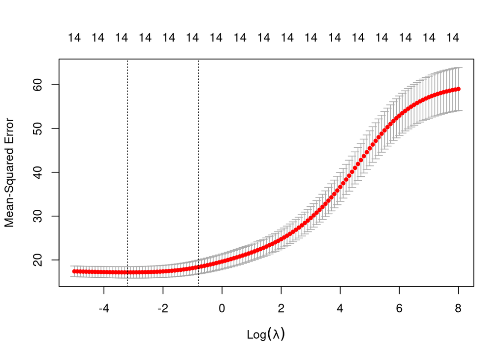

```r
library(faraway) #has the dataset fat
set.seed(1233)

#RIDGE REGRESSION

#we need to define the model equation
X <- model.matrix(brozek ~  age + weight +
                    height + adipos +
                    neck + chest +
                    abdom + hip + thigh +
                    knee + ankle +
                    biceps + forearm +
                    wrist, data=fat)[,-1]
#and the outcome
Y <- fat[,"brozek"]

#Penalty type (alpha=0 is ridge)
cv.lambda <- cv.glmnet(x=X, y=Y,
                       alpha = 0,
                       lambda=exp(seq(-5,8,.1)))

plot(cv.lambda)                                 #MSE for several lambdas
```

```r
cv.lambda$lambda.min
```

```
## [1] 0.0407622
```

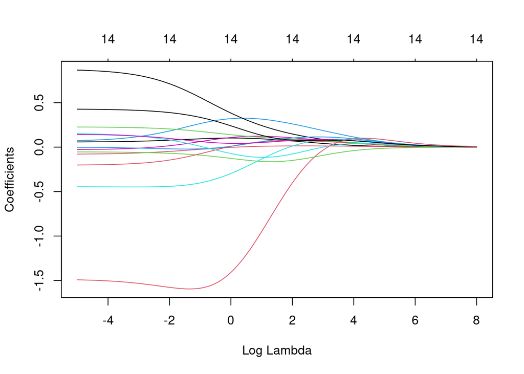

```r
#ridge path
plot(cv.lambda$glmnet.fit,
     "lambda", label=FALSE)
```

When lambda is high, the coefficients shrink toward zero.

#### Final Model

```r
lmin        <- cv.lambda$lambda.min
ridge.model <- glmnet(x=X, y=Y,
                      alpha = 0,
                      lambda = lmin)
ridge.model$beta
```

```
## 14 x 1 sparse Matrix of class "dgCMatrix"
##                  s0
## age      0.06507401
## weight  -0.06789165
## height  -0.06028540
## adipos   0.10207562
## neck    -0.45063815
## chest   -0.01601489
## abdom    0.81945358
## hip     -0.18402114
## thigh    0.22019252
## knee    -0.01128917
## ankle    0.12891779
## biceps   0.13023719
## forearm  0.41741050
## wrist   -1.51553984
```

#### Compare to OLS

```r
ols.regression <- lm(brozek ~  age + weight +                 #OLS
                       height + adipos +
                       neck + chest +
                       abdom + hip + thigh +
                       knee + ankle +
                       biceps + forearm +
                       wrist, data=fat)
#OLS vs RIDGE
round(cbind(OLS = coef(ols.regression),
            ridge = c(ridge.model$a0,                              #intercept for
                      as.vector(ridge.model$beta))),4)
```

```
##                  OLS    ridge
## (Intercept) -15.1901 -13.0910
## age           0.0569   0.0651
## weight       -0.0813  -0.0679
## height       -0.0531  -0.0603
## adipos        0.0610   0.1021
## neck         -0.4450  -0.4506
## chest        -0.0309  -0.0160
## abdom         0.8790   0.8195
## hip          -0.2031  -0.1840
## thigh         0.2274   0.2202
## knee         -0.0010  -0.0113
## ankle         0.1572   0.1289
## biceps        0.1485   0.1302
## forearm       0.4297   0.4174
## wrist        -1.4793  -1.5155
```

### LASSO Regression

$$\sum_{i=1}^n(y_i-\beta_0-\sum_{j=1}^p\beta_jx_{ij})^2+\lambda\sum_{j=1}^p|\beta_j|$$

Big Ideas:

- $\beta_j$ become zero
- Works like variable selection

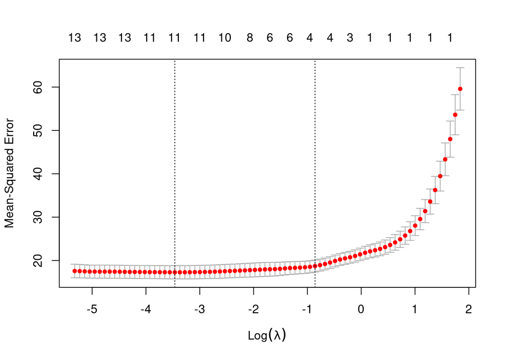

```r
#Penalty type (alpha=1 is lasso
#and alpha=0 is the ridge)
cv.lambda.lasso <- cv.glmnet(x=X, y=Y,
                             alpha = 1)
plot(cv.lambda.lasso)                        #MSE for several lambdas
```

```r
cv.lambda.lasso
```

```
##
## Call:  cv.glmnet(x = X, y = Y, alpha = 1)
##
## Measure: Mean-Squared Error
##
##     Lambda Index Measure    SE Nonzero
## min 0.0313    58   17.28 1.527      11
## 1se 0.4239    30   18.71 1.378       4
```

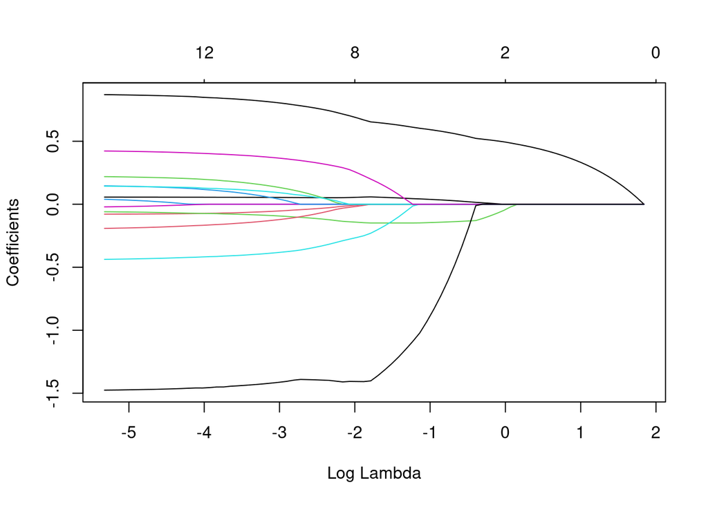

```r
#Lasso path
plot(cv.lambda.lasso$glmnet.fit,
     "lambda", label=FALSE)
```

#### Final Model

```r
l.lasso.min <- cv.lambda.lasso$lambda.min
l.lasso.min
```

```
## [1] 0.03132734
```

```r
lasso.model <- glmnet(x=X, y=Y,
                      alpha  = 1,
                      lambda = l.lasso.min)
lasso.model$beta
```

```
## 14 x 1 sparse Matrix of class "dgCMatrix"
##                  s0
## age      0.05461237
## weight  -0.06606504
## height  -0.08055424
## adipos   .
## neck    -0.40276110
## chest    .
## abdom    0.83148580
## hip     -0.14672738
## thigh    0.17130686
## knee     .
## ankle    0.08596538
## biceps   0.11316099
## forearm  0.38807121
## wrist   -1.43075188
```

### Ex 2: Birth Weights

In 2015, 20.5 million newborns, an estimated 14.6 per cent of all babies born globally that year, suffered from low birthweight.

Source: UNICEF

https://data.unicef.org/topic/nutrition/low-birthweight/

```r
lowbw<-read.csv("https://raw.githubusercontent.com/kitadasmalley/DATA252/main/Data/lowbwt.csv")

str(lowbw)
```

```
## 'data.frame':    189 obs. of  11 variables:
##  $ id   : int  85 86 87 88 89 91 92 93 94 95 ...
##  $ low  : int  0 0 0 0 0 0 0 0 0 0 ...
##  $ age  : int  19 33 20 21 18 21 22 17 29 26 ...
##  $ lwt  : int  182 155 105 108 107 124 118 103 123 113 ...
##  $ race : int  2 3 1 1 1 3 1 3 1 1 ...
##  $ smoke: int  0 0 1 1 1 0 0 0 1 1 ...
##  $ ptl  : int  0 0 0 0 0 0 0 0 0 0 ...
##  $ ht   : int  0 0 0 0 0 0 0 0 0 0 ...
##  $ ui   : int  1 0 0 1 1 0 0 0 0 0 ...
##  $ ftv  : int  0 3 1 2 0 0 1 1 1 0 ...
##  $ bwt  : int  2523 2551 2557 2594 2600 2622 2637 2637 2663 2665 ...
```

Variables:

- `id`= Identification Code
- `low`= Low Birth Weight Baby (1=Yes under 2500g, 0=No)
- `age`= Mother’s age in years
- `lwt`= Weight at Last Period
- `race`= Race (1=White, 2=Black, 3=Other)
- `smoke` = Smoke during Pregnancy (1=Yes, 0=No)
- `ptl`= History of Premature Labour (# of times)
- `ht`= History of Hypertension (1=Yes, 0=No)
- `ui` = Presence of Uterine Irritability (1=Yes, 0=No)
- `ftv`= Visits to Doctor During 1st trimester
- `bwt`= Baby’s birth Weight in Grams

#### Activities

Fit a linear model to predict birth weight (variable `bwt`) using all other predictors except for `low` and `id`.

- Create a graphic
- Perform stepwise regression to find the best variables to include in the model
- Perform Ridge and LASSO regression
- Compare the models

Source Examples from:

https://bookdown.org/tpinto_home/Regularisation/lasso-regression.html